# Аннотация

## Сколько игр выпускалось за разные годы?

```python
df_games['name'].nunique()
```

```
11426
```

```python
df_games_years = df_games.groupby('year_of_release').agg({'name': ['nunique']})
df_games_years.columns = ['games_number']
```

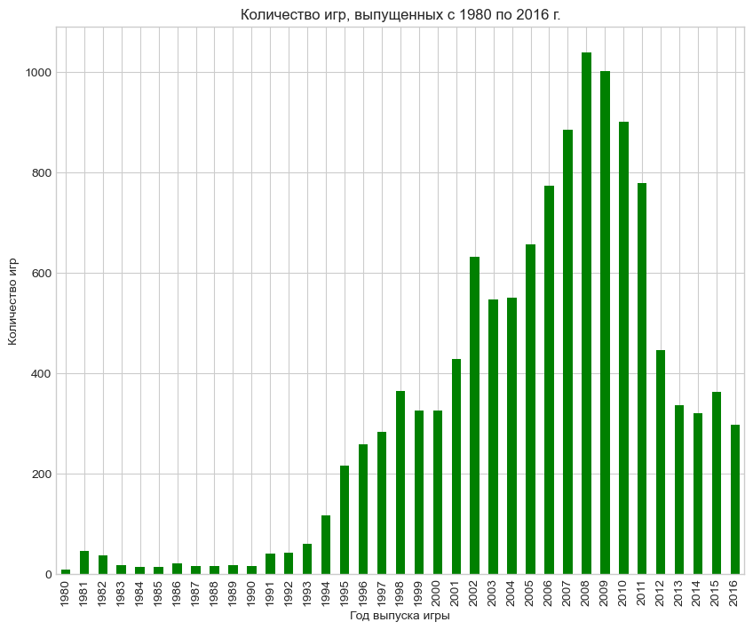

```python
ax = df_games_years.sort_values(by = 'year_of_release').plot(
    kind = 'bar',
    figsize = (10,8),
    title = "Количество игр, выпущенных с 1980 по 2016 г.",
    grid = True,
    xlabel = 'Год выпуска игры',
    ylabel = 'Количество игр',
    xlim = (1980, 2020),
    color = 'g',
    legend = False
    )


None
```

### Вывод:

Всего было выпущено 11426 уникальных игр за период с 1980 по 2016г.

Будем считать, что важный период для изучения истории видеоигр начинается с 1994 г., когда количество выпускаемых игр достигло 100 в год.  
Для понимания следующего года (2017) важен период с 2012 по 2016 гг., когда объем игр снизился по сравнению с предыдущим периодом, но оставался достаточно стабильным в течение 5 лет.

## Динамика продаж по платформам

```python
df_games['platform'].nunique()
```

```
31
```

Всего за все годы сменилась 31 платформа для игр. Посмотрим, какие платформы были самые популярные (с точки зрения суммарных продаж).

```python
platform_sales = df_games.groupby('platform').agg({'total_sales': 'sum'})
platform_sales.columns = ['total_sales']
```

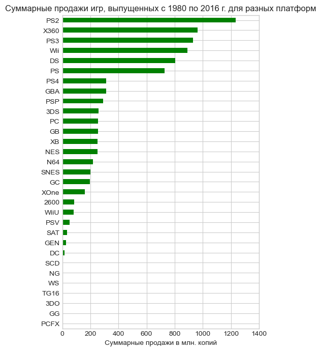

```python
platform_sales.sort_values('total_sales').plot(
    kind = 'barh',
    figsize = (5,8),
    title = "Суммарные продажи игр, выпущенных с 1980 по 2016 г. для разных платформ",
    grid = True,
    xlabel = 'Суммарные продажи в млн. копий',
    ylabel = ' ',
    xlim = (0, 1400),
    color = 'g',
    legend = False
)
None
```

### Посмотрим, как менялись продажи по наиболее популярным платформам

- На общем фоне выделяются 6 платформ с суммарными продажами более 600 млн.копий (у остальных 25 платформ суммарные продажи не достигают 400 млн.копий).
- Посмотрим, как менялись продажи по годам для первых 6 платформ в рейтинге продаж

```python
#создадим фильтр для платформ с наибольшим объемом продаж (более 600 млн копий)
platform_sales_top = platform_sales.loc[platform_sales['total_sales'] > 600]
```

```python
#Сколько игр приходится на 6 топовых платформ?
len(df_games.query('platform in @platform_sales_top.index'))
```

```
9262
```

```python
#соберем массив с объемом продаж по годам для 6 наиболее популярных платформ
df_top_platforms = (
    df_games.query('platform in @platform_sales_top.index')
    .groupby(['platform', 'year_of_release'])
    .agg({'total_sales':'sum'})
    .reset_index()
)
```

```python
df_top_platforms
```

|  | platform | year_of_release | total_sales |
| --- | --- | --- | --- |
| 0 | DS | 1985 | 0.02 |
| 1 | DS | 2004 | 17.27 |
| 2 | DS | 2005 | 130.14 |
| 3 | DS | 2006 | 119.81 |
| 4 | DS | 2007 | 146.94 |
| ... | ... | ... | ... |
| 62 | X360 | 2012 | 99.74 |
| 63 | X360 | 2013 | 88.58 |
| 64 | X360 | 2014 | 34.74 |
| 65 | X360 | 2015 | 11.96 |
| 66 | X360 | 2016 | 1.52 |

67 rows × 3 columns

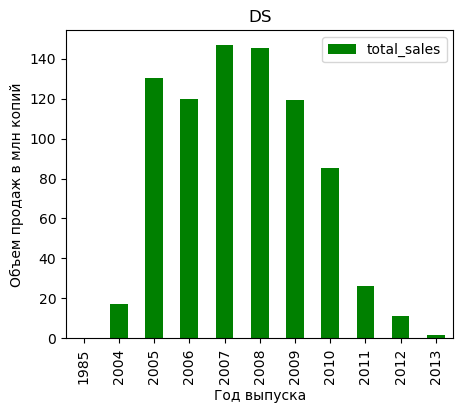

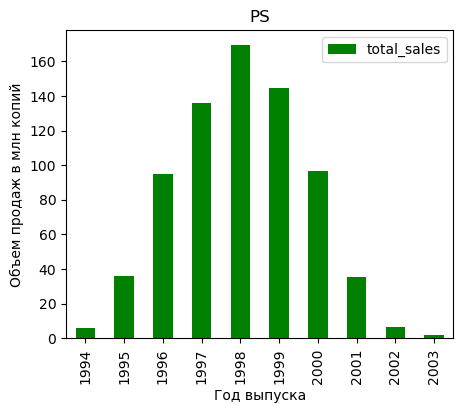

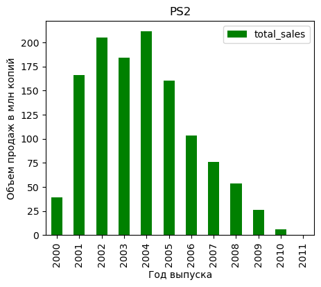

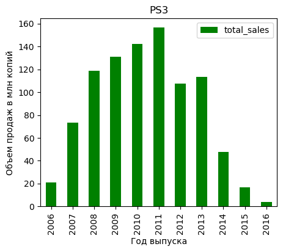

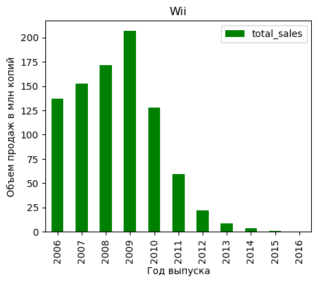

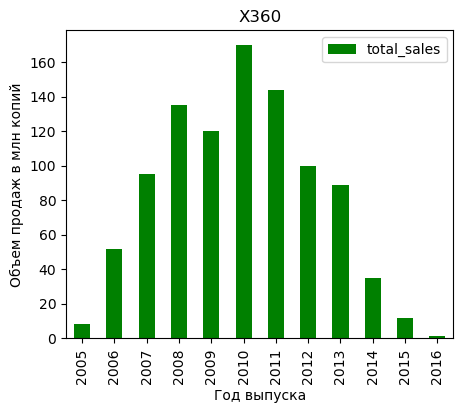

```python
# Построим диаграммы для 6 платформ: посмотрим годы, в которые активно продавались игры для каждой из них

for name, group_data in df_top_platforms.groupby('platform'):
    group_data.plot(
        y = 'total_sales',
        x = 'year_of_release',
        kind = 'bar',
        figsize = (5,4),
        ylabel = 'Объем продаж в млн копий',
        xlabel = 'Год выпуска',
        color = 'g',
        title = name)
```

```python
#Рейтинг наиболее популярных платформ по объемам продаж в млн.копий
platform_sales_top.sort_values('total_sales', ascending = False)
```

| platform | total_sales |
| --- | --- |
| PS2 | 1233.56 |
| X360 | 961.24 |
| PS3 | 931.34 |
| Wii | 891.18 |
| DS | 802.78 |
| PS | 727.58 |

### Вывод:

Каждая из платформ-лидеров успешно продавалась в соответсвтующие годы:

- PS2(1233,56 млн копий) с 2000 по 2011 гг, наиболее успешные - 2002 - 2005 гг.
- Х360 (961,24 млн копий) с 2005 по 2016 гг, наиболее успешные - 2007 - 2012 гг.
- PS3 (931,34 млн.копий) с 2006 по 2016 гг, наиболее успешные - 2008 - 2013 гг.
- WII (891,18 млн.копий) с 2006 по 2016 гг, наиболее успешные - 2006 - 2010 гг.
- DS (802,78 млн.копий) с 2004 по 2013 гг, наиболее успешные - 2005 - 2010 гг.
- PS (727,78 млн.копий) с 1994 по 2003 гг, наиболее успешные - 1996 - 2000 гг.

Таким образом, одна платформа "живет" в среднем 10 лет; цикл жизни большинства платформ соответствует нормальному распределению: первые 2-3 года платформа набирает популярность, потом 4-5 лет можно наблюдать активные продажи, и далее постепенно популярность падает, на смену приходя новые платформы.

Наиболее продаваемой за все годы была платформа PS2: за 12 лет для нее было продано 1233,56 млн копий видеоигр.

## Анализ продаж видеоигр в 2012-2016 гг.

```python
# возьмем срез данных за 2012 - 2016 гг.
games_set = df_games.loc[df_games['year_of_release'] >= 2012]
```

```python
#посмотрим наполненность массива
games_set.info()
```

```
<class 'pandas.core.frame.DataFrame'>
Index: 2886 entries, 16 to 16714
Data columns (total 12 columns):
 #   Column           Non-Null Count  Dtype
---  ------           --------------  -----
 0   name             2886 non-null   object
 1   platform         2886 non-null   object
 2   year_of_release  2886 non-null   int64
 3   genre            2886 non-null   object
 4   na_sales         2886 non-null   float64
 5   eu_sales         2886 non-null   float64
 6   jp_sales         2886 non-null   float64
 7   other_sales      2886 non-null   float64
 8   critic_score     1312 non-null   float64
 9   user_score       1531 non-null   float64
 10  rating           1611 non-null   object
 11  total_sales      2886 non-null   float64
dtypes: float64(7), int64(1), object(4)
memory usage: 293.1+ KB
```

```python
# проверим долю пропущенных данных в переменных
games_set.isnull().sum()/len(games_set)
```

```
name               0.000000
platform           0.000000
year_of_release    0.000000
genre              0.000000
na_sales           0.000000
eu_sales           0.000000
jp_sales           0.000000
other_sales        0.000000
critic_score       0.545392
user_score         0.469508
rating             0.441788
total_sales        0.000000
dtype: float64
```

Доля пропусков в отфильтрованном массиве сопоставима с пропусками в исходных данных.

### Платформы-лидеры продаж

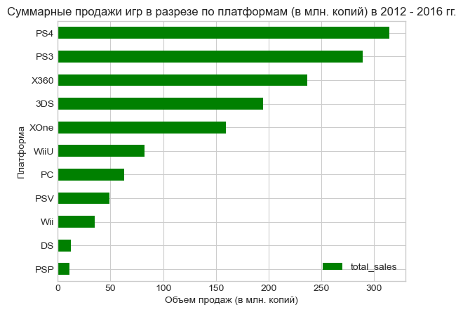

```python
(games_set.groupby('platform')
    .agg({'total_sales': 'sum'})
    .sort_values('total_sales').plot(
    kind = 'barh',
    color = 'g',
    title = 'Суммарные продажи игр в разрезе по платформам (в млн. копий) в 2012 - 2016 гг.',
    ylabel = 'Платформа',
    xlabel = 'Объем продаж (в млн. копий)'

)
)
None
```

```python
#Сгруппируем массив по году и платформе
games_set_group = (
    games_set.groupby(['platform', 'year_of_release'])
    .agg({'total_sales':'sum'})
    .reset_index()
)
```

```python
#создадим сводную таблицу, где для каждой платформы записаны продажи по годам
games_set_pivot = (games_set_group
                   .pivot_table(index = 'platform', columns = 'year_of_release', values = 'total_sales', aggfunc = 'sum')
                  )
#переименуем столбцы
games_set_pivot.columns = [2012, 2013, 2014, 2015, 2016]
```

```python
#добавим столбец с суммарными продажами за 6 лет, чтобы отсортировать наиболее продаваемые платформы за эти годы
games_set_pivot['total_sales'] = games_set_pivot[[2012, 2013, 2014,2015,2016]].sum(axis = 1)
games_set_pivot.sort_values('total_sales', ascending = False)
```

| platform | 2012 | 2013 | 2014 | 2015 | 2016 | total_sales |
| --- | --- | --- | --- | --- | --- | --- |
| PS4 | NaN | 25.99 | 100.00 | 118.90 | 69.25 | 314.14 |
| PS3 | 107.36 | 113.25 | 47.76 | 16.82 | 3.60 | 288.79 |
| X360 | 99.74 | 88.58 | 34.74 | 11.96 | 1.52 | 236.54 |
| 3DS | 51.36 | 56.57 | 43.76 | 27.78 | 15.14 | 194.61 |
| XOne | NaN | 18.96 | 54.07 | 60.14 | 26.15 | 159.32 |
| WiiU | 17.56 | 21.65 | 22.03 | 16.35 | 4.60 | 82.19 |
| PC | 23.22 | 12.38 | 13.28 | 8.52 | 5.25 | 62.65 |
| PSV | 16.19 | 10.59 | 11.90 | 6.25 | 4.25 | 49.18 |
| Wii | 21.71 | 8.59 | 3.75 | 1.14 | 0.18 | 35.37 |
| DS | 11.01 | 1.54 | NaN | NaN | NaN | 12.55 |
| PSP | 7.69 | 3.14 | 0.24 | 0.12 | NaN | 11.19 |

Для наглядности построим график изменения объемов продаж по первым 5 платформам (лидерам по объему продаж).

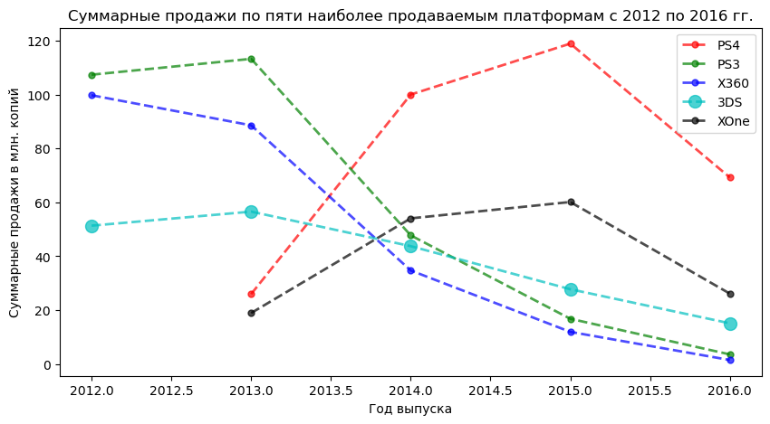

```python
#для каждой платформы мы можем взять из таблицы продажи по годам
x = [2012, 2013, 2014, 2015, 2016]
y1 = list(round(games_set_pivot.loc['PS4', 2012 : 2016], 2))
y2 = list(round(games_set_pivot.loc['PS3', 2012 : 2016], 2))
y3 = list(round(games_set_pivot.loc['X360', 2012 : 2016], 2))
y4 = list(round(games_set_pivot.loc['3DS', 2012 : 2016], 2))
y5 = list(round(games_set_pivot.loc['XOne', 2012 : 2016], 2))


plt.figure(figsize=(10, 5))
plt.plot(x, y1, 'o--r', alpha=0.7, label="PS4", lw=2, mec='r', mew=1, ms=5)
plt.plot(x, y2, 'o--g', alpha=0.7, label="PS3", lw=2, mec='g', mew=1, ms=5)
plt.plot(x, y3, 'o--b', alpha=0.7, label="X360", lw=2, mec='b', mew=1, ms=5)
plt.plot(x, y4, 'o--c', alpha=0.7, label="3DS", lw=2, mec='c', mew=1, ms=10)
plt.plot(x, y5, 'o--k', alpha=0.7, label="XOne", lw=2, mec='k', mew=1, ms=5)

plt.legend()
plt.title ('Суммарные продажи по пяти наиболее продаваемым платформам с 2012 по 2016 гг.')
plt.ylabel ('Суммарные продажи в млн. копий')
plt.xlabel ('Год выпуска')
plt.show()
```

#### Вывод:

- У платформ PS3, X360 и 3DS продажи к 2016 г. планомерно снижались, вряд ли в 2016 г будет рост.
- Продажи XOne и PS4 начали расти с 2013 г. Вероятно, за 2016 г. данные не полные, и продажи этих платформ либо продолжают расти, либо стабильны.
- Из всех платформ XOne и PS4 можно считать перспективными и потенциально прибыльными.

### Глобальные продажи игр в разбивке по платформам.

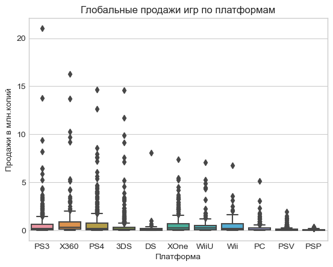

```python
plt.style.use('seaborn-whitegrid')
(
sns.boxplot(y='total_sales', x='platform', data=games_set)
 .set (title='Глобальные продажи игр по платформам', xlabel = 'Платформа', ylabel = 'Продажи в млн.копий')
)
plt.show()
```

Есть аномально-большие продажи отдельных игр, сложно сравнивать средние продажи.

Ограничим продажи числом 2 млн. копий.

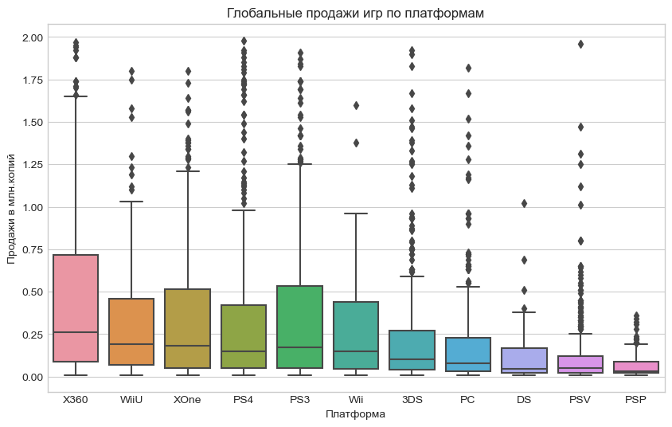

```python
#создаем переменную для сортировки
order_sales = (games_set.groupby('platform')['total_sales']
               .median().reset_index().sort_values('total_sales', ascending = False)
              )

#строим график
plt.style.use('seaborn-whitegrid')
plt.figure(figsize=(10,6))

(
sns.boxplot(y='total_sales', x='platform',
            data=games_set.query('total_sales <= 2'),
            order = order_sales['platform'],
          )
            .set (title='Глобальные продажи игр по платформам', xlabel = 'Платформа', ylabel = 'Продажи в млн.копий')

)

plt.show()
```

Диаграмма размаха позволяет увидеть (1) разницу медианного показателя объемов продаж игр отдельных платформ в актуальном периоде, (2) платформы, которые выделяются на фоне других по играм с (аномально) высокими продажами.

Пятерка лидеров платформы со стабильно высокими продажами по половине разработанных игр:

- X360
- PS3
- PS4
- XOne
- WiiU и Wii

### Как отзывы пользователей и критиков влияют на продажи?

#### Как отзывы пользователей и критиков влияют на продажи глобально?

```python
# корреляция рейтинга пользователей и продаж в целом (за 2012-2016)
games_set['total_sales'].corr(games_set['user_score'])
```

```
0.004428817675493266
```

```python
# корреляция рейтинга критиков и продаж в целом (за 2012-2016)
games_set['total_sales'].corr(games_set['critic_score'])
```

```
0.308196745920778
```

Корреляция продаж и рейтинга критиков очень слабая; корреляция продаж и рейтингов пользователей, можно сказать, отсутствует.

#### Как отзывы пользователей и критиков влияют на продажи платформ-лидеров? Пример популярной платформы PS4

```python
#Посмотрим, какие данные об отзывах есть в распоряжении об одной из популярных платформ
games_set.query('platform == "PS4"')['user_score'].describe()
```

```
count    257.000000
mean       6.748249
std        1.459481
min        1.500000
25%        6.100000
50%        7.000000
75%        7.800000
max        9.200000
Name: user_score, dtype: float64
```

```python
games_set.query('platform == "PS4"')['critic_score'].describe()
```

```
count    252.000000
mean      72.091270
std       12.485992
min       19.000000
25%       66.000000
50%       73.000000
75%       80.000000
max       97.000000
Name: critic_score, dtype: float64
```

Как в распределении оценок пользователей, так и в распределении оценок критиков средние и медианные значения близки; оценки распределоены равномерно, нет "выбросов", значимо влияющих на распределение оценок.

Посмотрим корелляцию рейтингов и продаж.

```python
#Рейтинг пользователей и продажи
games_set_PS4 = games_set.loc[games_set['platform'] == 'PS4']
```

```python
games_set_PS4['total_sales'].corr(games_set_PS4['user_score'])
```

```
-0.031957110204556424
```

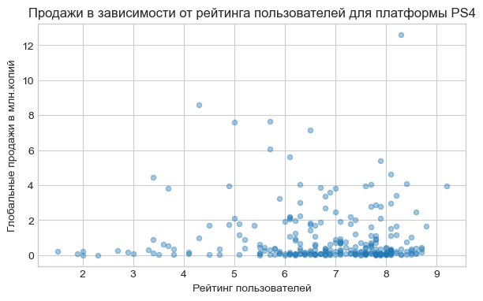

```python
games_set_PS4.plot(
     kind = 'scatter',
     figsize = (7,4),
     x = 'user_score',
     y = 'total_sales',
     title = 'Продажи в зависимости от рейтинга пользователей для платформы PS4',
     alpha = 0.4,
     xlabel = "Рейтинг пользователей",
     ylabel = 'Глобальные продажи в млн.копий'
 )
None
```

```python
games_set_PS4['total_sales'].corr(games_set_PS4['critic_score'])
```

```
0.406567902061781
```

Корреляция продаж игр платформы PS4 с отзывами критиков слабая, но все-таки есть.

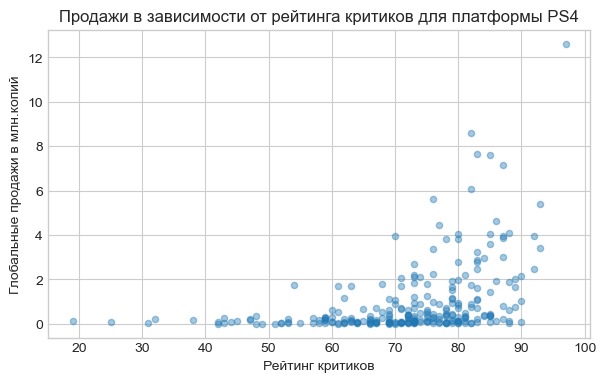

```python
games_set_PS4.plot(
     kind = 'scatter',
     figsize = (7,4),
     x = 'critic_score',
     y = 'total_sales',
     title = 'Продажи в зависимости от рейтинга критиков для платформы PS4',
     alpha = 0.4,
     xlabel = "Рейтинг критиков",
     ylabel = 'Глобальные продажи в млн.копий'
 )
None
```

График позволяет предположить, что в сегменте с более высокими оценками критиков(60+) связь рейтинга и продаж выражена сильнее. Однако коэффициент корреляции по прежнему говорит о слабой связи. Высокие продажи для игр с высокими оценками критиков характерны для отдельных игр, но не для сегмента в целом.

```python
games_set_PS4.query('critic_score > 70')['critic_score'].corr(games_set_PS4.query('critic_score > 60')['total_sales'])
```

```
0.42986570648214895
```

#### Как отзывы пользователей и критиков влияют на продажи: все игровые платформы за актуальный период

##### Отзывы пользователей

```python
# посчитаем коэффициент корреляции продаж и рейтинга пользователей для всех платформ в актуальных данных(2012-2016 гг.)

for platform in games_set['platform'].unique():
    data_query = games_set.query('platform == @platform')
    print(f"{platform}: {round(data_query['total_sales'].corr(data_query['user_score']), 2)}")
```

```
PS3: -0.01
X360: 0.01
PS4: -0.03
3DS: 0.2
DS: 0.88
XOne: -0.07
WiiU: 0.4
Wii: 0.3
PC: -0.12
PSV: -0.0
PSP: -0.8
```

Среди всех платформ, только для DS наблюдается высокая положительная корреляция рейтингов пользователей с продажами, для PSP - напротив, высокая отрицательная. Из этого сложно сделать какие-либо выводы: на графиках ниже видно, что для этих платформ достаточно мало единиц наблдения.

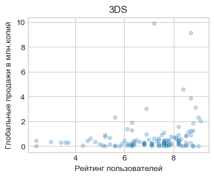

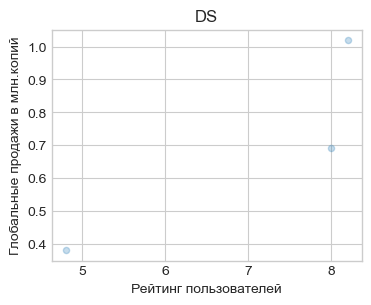

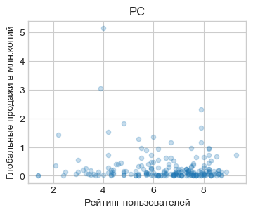

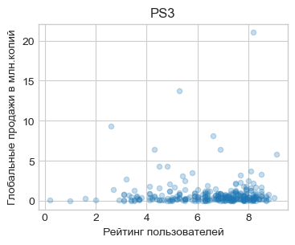

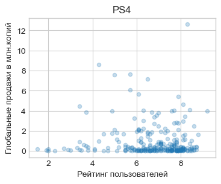

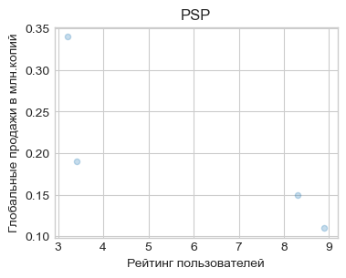

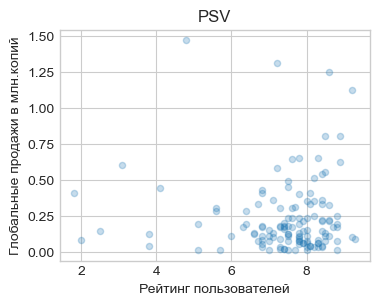

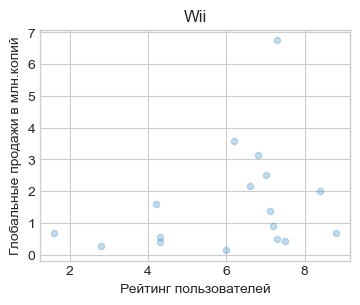

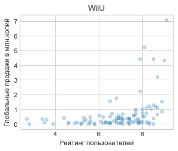

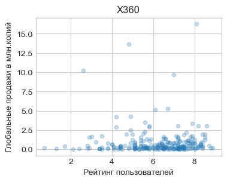

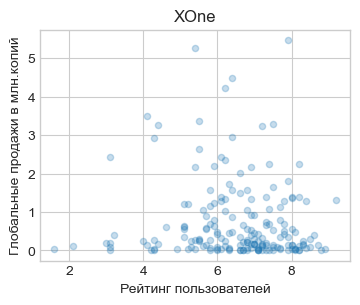

```python
# построим диаграммы рассеяния продаж и рейтинга пользователей для всех платформ в актуальных данных(2012-2016 гг.)
for name, group_data in games_set.groupby('platform'):
    group_data.plot(
        kind = 'scatter',
        figsize = (4,3),
        x = 'user_score',
        y = 'total_sales',
        ylabel = 'Глобальные продажи в млн.копий',
        xlabel = 'Рейтинг пользователей',
        title = name,
        alpha = 0.25)
    None
```